# MTH6139 Time Series

A Forecast of Russian Military Personnel Losses

James Zhao

Spring term 2025

## Load and prepare data

This dataset is from kaggle and displays time-series of a multitude of different counts such aas equipment. I’ve isolated the military personnel losses and the dates span the length of the conflict.The count is cumulative so this does mean that we should expect to see an upwards trend.

```r
library(prophet)
data <- read.csv("data/russia_losses.csv")

prophet_data <- data.frame(
  ds = as.Date(data$date),
  y = data$personnel_losses
)
```

# Forecasting Russian Military Personel Losses

## Intro

This is an analysis of a time series with a daily count of military personnel losses. We will use Meta’s Prophet forecasting model to understand the long-term trends and the short-term forecasts.

## EDA

Plotting the raw data, we get:

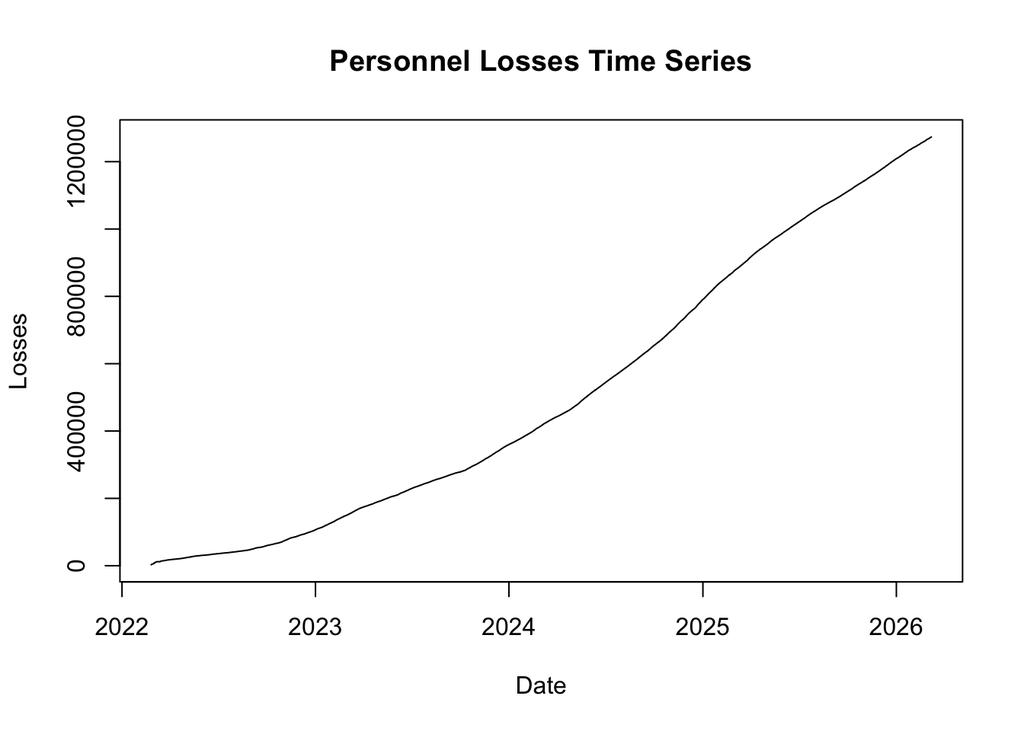

```r
plot(prophet_data$ds, prophet_data$y, type="l",
     main="Personnel Losses Time Series",
     xlab="Date",
     ylab="Losses")
```

## Prophet Forecast

There is no stand out seasonal pattern as the series is driven by conflict, politics etc rather than calender effects. We’ll use a forecast of 30 days as long term time parameters would be more subject to inaccuracy due to the highly political nature of the time series.

```r
model <- prophet(prophet_data)
```

```
## Disabling daily seasonality. Run prophet with daily.seasonality=TRUE to override this.
```

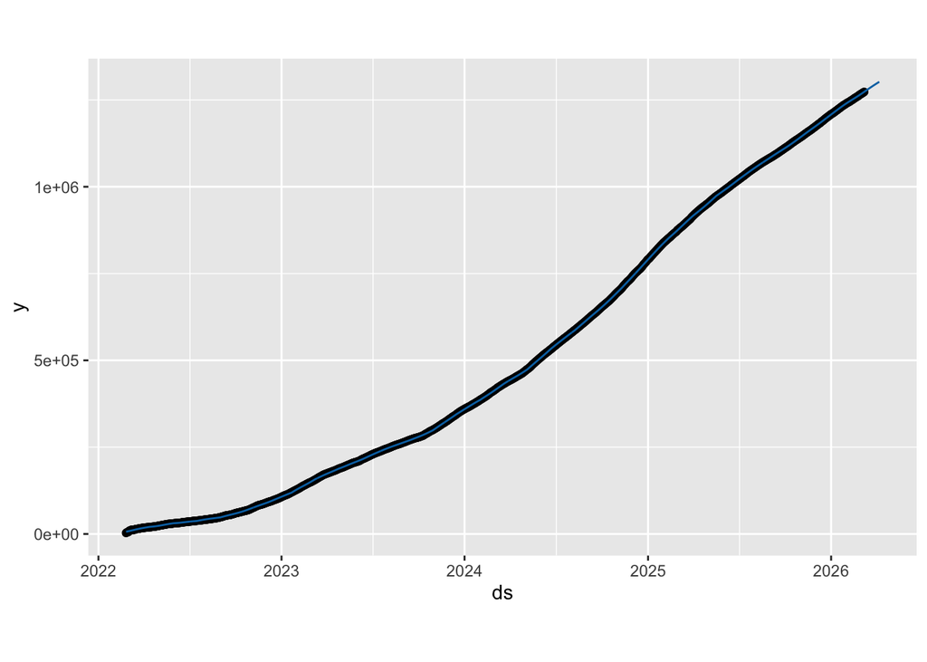

```r
future <- make_future_dataframe(model, periods = 30)
forecast <- predict(model, future)
plot(model, forecast)
```

Since the data is cumulative and strongly trending (as we expect), a log transformation can be used to cut down on variance and normalize growth intepretations.

## Daily change analysis

To understand the dynamics of the series, we can compute the daily change in personnel losses:

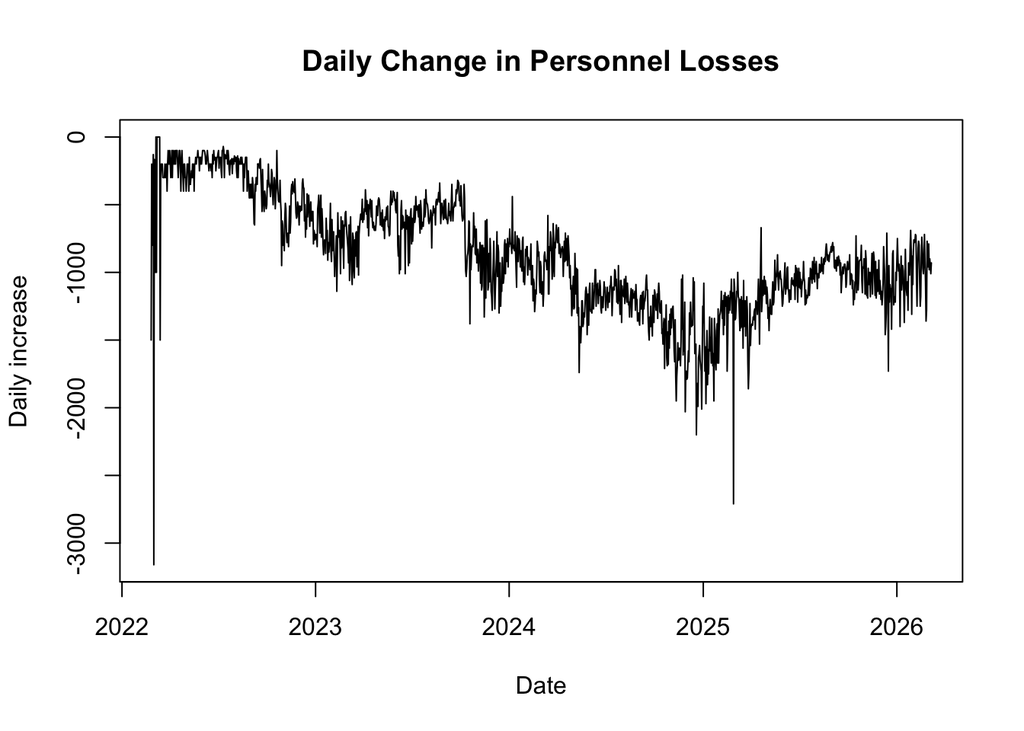

```r
daily_change <- diff(prophet_data$y)

plot(prophet_data$ds[-1], daily_change, type="l",
     main="Daily Change in Personnel Losses",
     xlab="Date",
     ylab="Daily increase")
```

As we can see, the increase in losses isn’t constant, there’s high variation in the intensity of events over time.

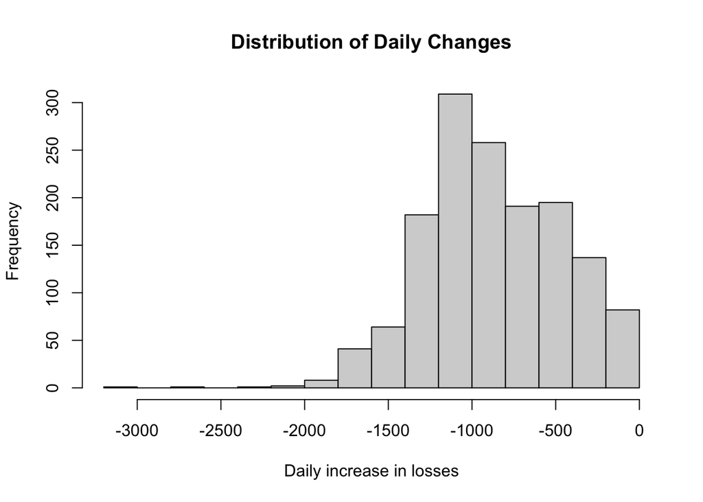

```r
hist(daily_change,
     main = "Distribution of Daily Changes",
     xlab = "Daily increase in losses")
```

## Simple Regression

```r
time_index <- 1:nrow(prophet_data)
linear_model <- lm(y ~ time_index, data = prophet_data)
summary(linear_model)
```

```
##
## Call:
## lm(formula = y ~ time_index, data = prophet_data)
##
## Residuals:
##    Min     1Q Median     3Q    Max
## -98445 -69638  -6405  63270 174899
##
## Coefficients:
##              Estimate Std. Error t value Pr(>|t|)
## (Intercept) 1194839.1     3828.6   312.1   <2e-16 ***
## time_index     -927.6        4.5  -206.1   <2e-16 ***
## ---
## Signif. codes:  0 '***' 0.001 '**' 0.01 '*' 0.05 '.' 0.1 ' ' 1
##
## Residual standard error: 73430 on 1471 degrees of freedom
## Multiple R-squared:  0.9665, Adjusted R-squared:  0.9665
## F-statistic: 4.249e+04 on 1 and 1471 DF,  p-value: < 2.2e-16
```

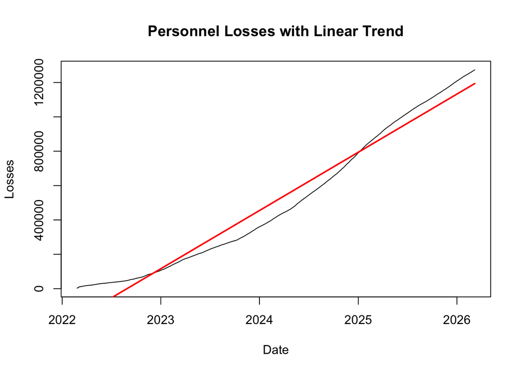

```r
plot(prophet_data$ds, prophet_data$y, type = "l",
     main = "Personnel Losses with Linear Trend",
     xlab = "Date",
     ylab = "Losses")

lines(prophet_data$ds, fitted(linear_model),
      col = "red", lwd = 2)
```

## Summary Statistics

```r
summary(prophet_data$y)
```

```
##    Min. 1st Qu.  Median    Mean 3rd Qu.    Max.
##    2800  149240  415640  511224  880660 1273290
```

```r
tail(forecast[, c("ds","yhat","yhat_lower","yhat_upper")])
```

```
##              ds    yhat yhat_lower yhat_upper
## 1498 2026-04-02 1297690    1296495    1299127
## 1499 2026-04-03 1298607    1297366    1300052
## 1500 2026-04-04 1299518    1298148    1301036
## 1501 2026-04-05 1300430    1299173    1301966
## 1502 2026-04-06 1301319    1299973    1303079
## 1503 2026-04-07 1302237    1300826    1304157
```

These summary statistics and forecast values help quantify the scale of the series and the uncertainty in the model output.

## Conclusion

This write up analyzed a daily time series dataset of Russian Military Personnel losses and used Meta’s Prophet model to produce a forecast. The EDA showed a clear upwards trend in cumulative losses over time.

Te prophet model generated forecast for the next 30 days. The widening uncertainty interval in the forecast highlights the increasing level of unpredictability further into the future.